# Nested Resource Competition Models

Ruby An

2023-02-01

# 1 Introduction

This file is for conceptually and quantitatively exploring the basis of resource competition theory (Tilman 1982, 1988). Some motivating questions include:

1. From simple models of competition for resources, what qualititave system behaviors emerge?
2. How do we understand community dynamics in an era of global change in light of resource competition theory?

1. Diagrams/Equations (with verbal description)
2. Analytical Solution
3. Timeseries plots / Consumer/resource phase planes
4. Bifurcation plot based on a parameter (list of possible dynamics)
5. Summary plot (model outcome heatmap w/two parameters)

# 2 One consumer, one resource

## 2.1 Model Description

A simple model for a single species of plant growing with one resource. This is a basic set of equations for modeling one consumer ($B$) and one resource ($R$).

$$\begin{aligned}
\frac{dB}{dt} &= f \frac{gR}{1+ ghR}B - L B \\
\frac{dR}{dt} &= r - \frac{gR}{1+ ghR}B \\
\end{aligned}$$
Total biomass ($B$) is determined by the net balance between growth and loss rates. The growth rate per unit biomass is a function of resource availability, given by $G(R) = f \frac{g R}{1+ g h R}$, where $f$ is the resource conversion efficiency, $g$ is uptake rate constant, and $h$ controls the saturation rate of uptake. $G(R)$ is linear when $h = 0$, and saturates with increasing $R$ when $h > 0$. This model assumes a fixed loss rate $L$ per unit biomass.

### 2.1.1 Set Parameter Values

The following plots use the parameter values listed below.

| name | value | description |
| --- | --- | --- |
| r | 0.5 | resource supply rate |
| g | 0.5 | per unit growth rate |
| f | 1.0 | resource conversion efficiency |
| h | 0.2 | uptake saturation |
| L | 0.7 | biomass loss rate |

## 2.2 Analytical Solution

For this system of equations, $R^*$ can be analytically calculated by setting $\frac{dB}{dt} = 0$. By this definition, $R^*$ is the resource level where biomass growth exactly balances loss and thus the minimum resource level required to sustain a non-zero biomass.

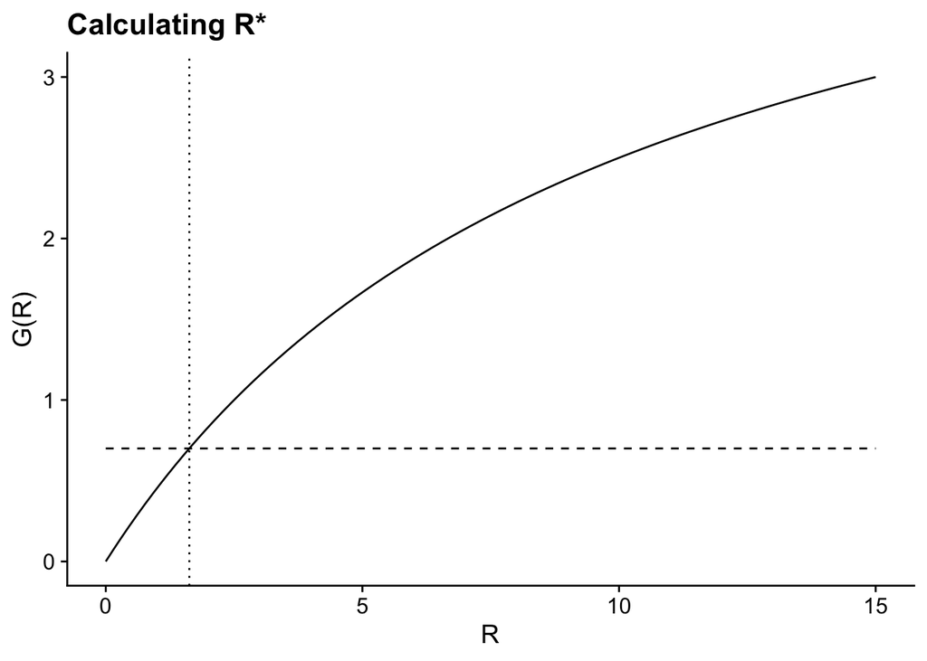

Graphically, the value of $R^*$ is where the growth rate curve $G(R)$ curve crosses the loss-rate curve $L$. We see that increasing the loss rate (horizontal line) increases the value of $R^*$ given the monotonically increasing curve $G(R)$.

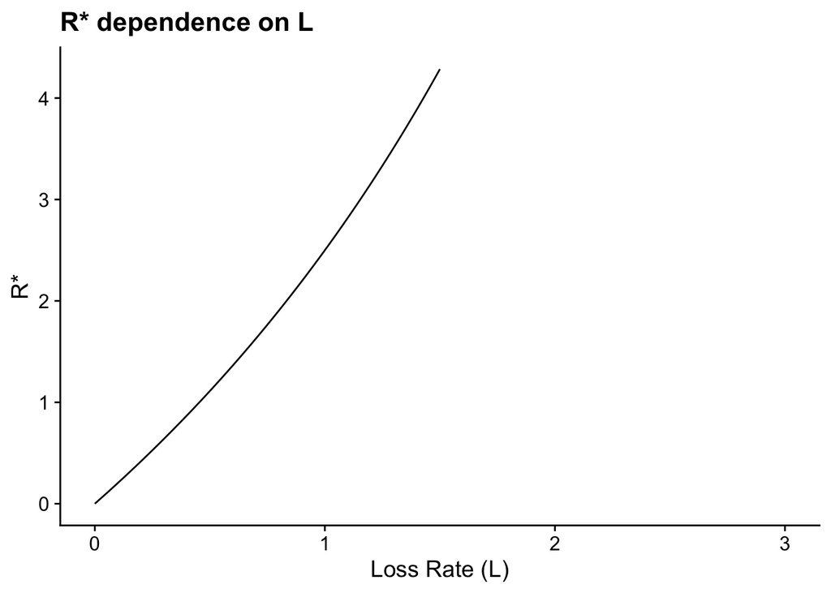

The analytical solution of this simple system, $R^* = \frac{L}{fg - hgL}$ implies that $R^*$ increases with the loss rate ($L$). Note that $R^*$ (but not $B^*$) is independent of the resource supply rate ($r$). Introducing a handling time term $h > 0$ means that at a certain loss rate ($L = f/h$ = 5), the value of $R^*$ goes to infinity.

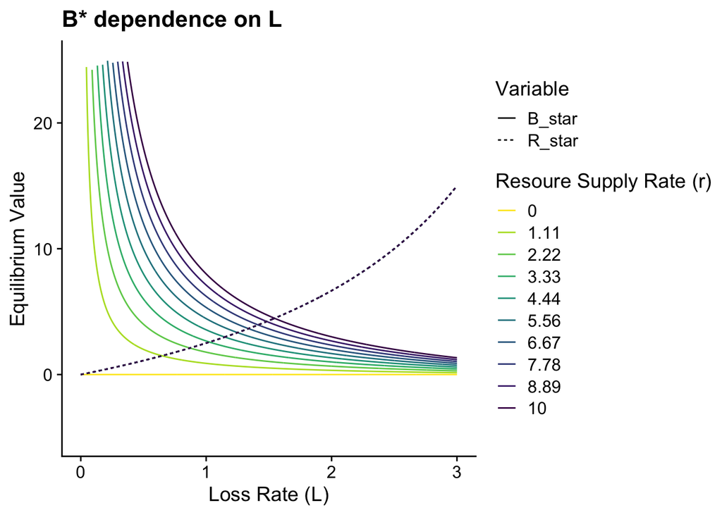

The amount of biomass $B^*$ that can be sustained depends on the resource supply rate (r).

## 2.3 Timeseries & Phase Plane

We can numerically integrate one instance. Analytical solutions predict values of `B` and `R` at equilbirium (dashed lines).

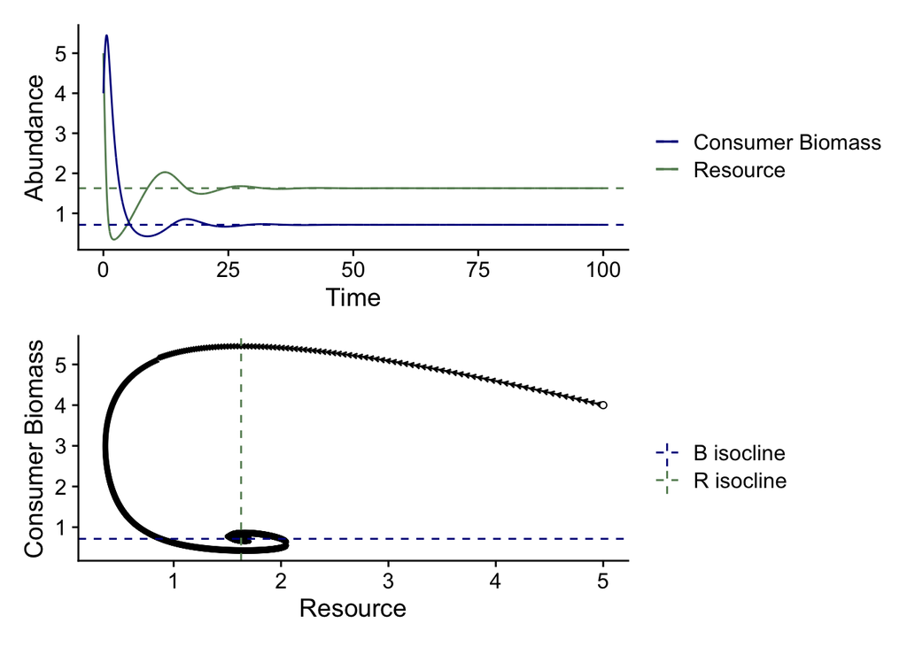

## 2.4 Equilibrium Outcomes

### 2.4.1 Parameter Scan

Summary plot of the dynamics/equilibrium values of the model.

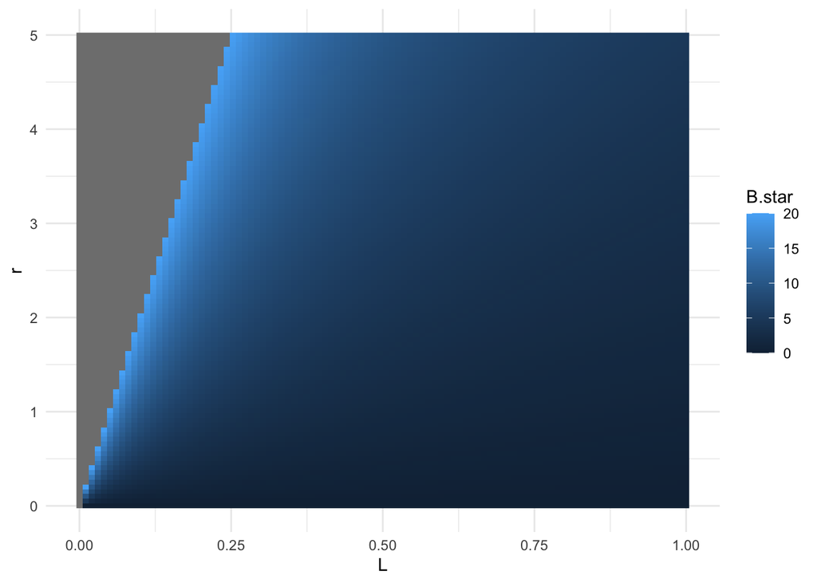

Biomass heatmap shows that biomass at equilibrium increases with resource supply rate `r` and decreases with loss rate `L`.

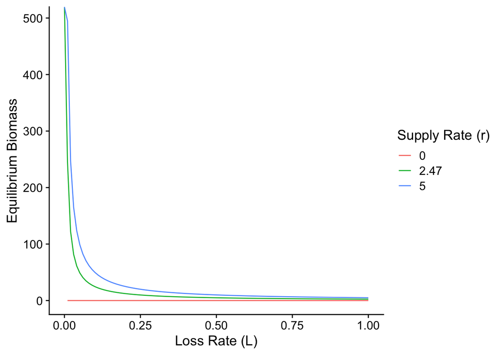

# 3 Two consumers, one resource

## 3.1 Model Description

A simple model for two species ($B_1$ and $B_2$) competing for one resource ($R$). Consumers interact solely by competing for a shared resource.

$$\begin{aligned}
\frac{dB_{1}}{dt} &= f_{1} \frac{g_{1}R}{1+ g_{1}h_{1}R}B_{1} -
L_{1} B_{1} \\
\frac{dB_{2}}{dt} &= f_{2} \frac{g_{2}R}{1+ g_{2}h_{2}R}B_{2} -
L_{2} B_{2} \\
\frac{dR}{dt} &= r - \frac{g_{1}R}{1+ g_{1}h_{1}R}B_{1} -
\frac{g_{2}R}{1+ g_{2}h_{2}R}B_{2}\\
\end{aligned}$$

Parameters are as described in the model for one consumer and one resource.

### 3.1.1 Set Parameter Values

The following plots use the parameter values listed below.

| name | value | description |
| --- | --- | --- |
| r | 0.50 | resource supply rate |
| g1 | 1.00 | sp. 1 per unit growth rate |
| f1 | 0.50 | sp. 1 resource conversion efficiency |
| h1 | 0.75 | sp. 1 uptake saturation |
| L1 | 0.50 | sp. 1 biomass loss rate |
| g2 | 0.25 | sp. 2 per unit growth rate |
| f2 | 0.50 | sp. 2 resource conversion efficiency |
| h2 | 0.50 | sp. 2 uptake saturation |
| L2 | 0.50 | sp. 2 biomass loss rate |

## 3.2 Analytical Solution

For this system of equations, $R^*$ can be analytically calculated by setting $\frac{dB}{dt} = 0$. By this definition, $R^*$ is the resource level where biomass growth exactly balances loss and thus the minimum resource level required to sustain a non-zero biomass.

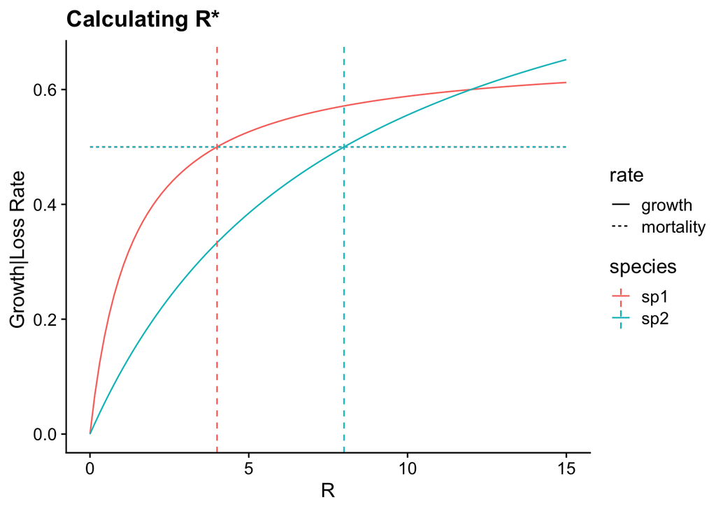

The species with the lower $R^*$ will outcompete the other.

## 3.3 Timeseries & Phase Plane

We can numerically integrate one instance. Analytical solutions predict values of $B_1$, $B_2$ and $R$ at equilbirium (dashed lines).

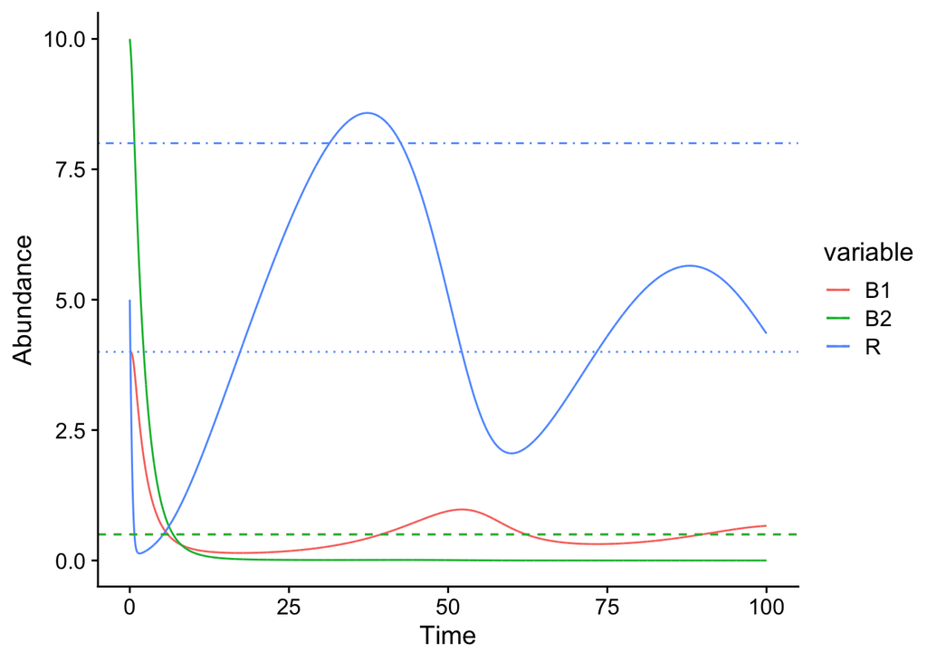

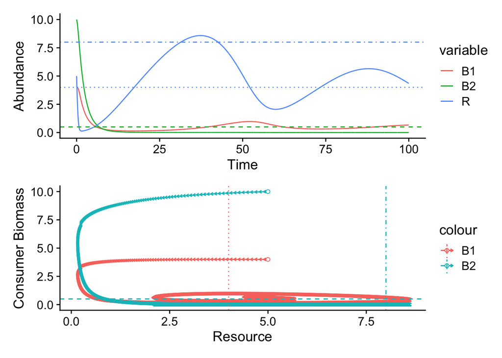

## 3.4 Equilibrium Outcomes

There are a number of possible outcomes at equilibrium.

1. No species can be sustained.
2. R* (sp1) < R* (sp2) - Sp. 1 wins
3. R* (sp2) < R* (sp1) - Sp. 2 wins

### 3.4.1 Parameter Scan

```
##          L1  L2   r g1  f1   h1   g2  f2  h2  R.star.1  R.star.2  B1.star
## 1 0.1000000 0.1 0.5  1 0.5 0.75 0.25 0.5 0.5 0.2352941 0.8888889 2.500000
## 2 0.1019019 0.1 0.5  1 0.5 0.75 0.25 0.5 0.5 0.2405766 0.8888889 2.453340
## 3 0.1038038 0.1 0.5  1 0.5 0.75 0.25 0.5 0.5 0.2458948 0.8888889 2.408390
## 4 0.1057057 0.1 0.5  1 0.5 0.75 0.25 0.5 0.5 0.2512491 0.8888889 2.365057
## 5 0.1076076 0.1 0.5  1 0.5 0.75 0.25 0.5 0.5 0.2566398 0.8888889 2.323256
## 6 0.1095095 0.1 0.5  1 0.5 0.75 0.25 0.5 0.5 0.2620673 0.8888889 2.282907
##   B2.star   B.star sp
## 1     2.5 2.500000  1
## 2     2.5 2.453340  1
## 3     2.5 2.408390  1
## 4     2.5 2.365057  1
## 5     2.5 2.323256  1
## 6     2.5 2.282907  1
```

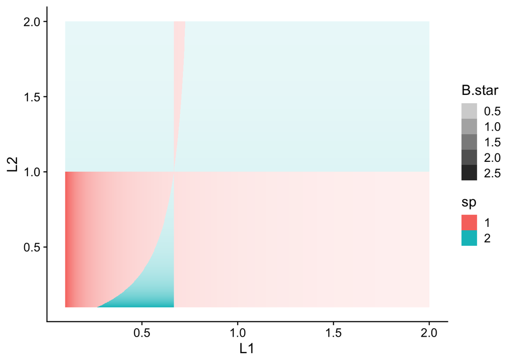

# 4 Two consumers, one fluctuating resource

## 4.1 Model Description

A simple model for two species ($B_1$ and $B_2$) competing for one resource ($R$) with a supply rate that varies in time. Consumers interact solely by competing for a shared resource.

$$\begin{aligned}
\frac{dB_{1}}{dt} &= f_{1} \frac{g_{1}R}{1+ g_{1}h_{1}R}B_{1} -
L_{1} B_{1} \\
\frac{dB_{2}}{dt} &= f_{2} \frac{g_{2}R}{1+ g_{2}h_{2}R}B_{2} -
L_{2} B_{2} \\
\frac{dR}{dt} &= r(t) - \frac{g_{1}R}{1+ g_{1}h_{1}R}B_{1} -
\frac{g_{2}R}{1+ g_{2}h_{2}R}B_{2}\\
r(t) &= \sin(\beta t)
\end{aligned}$$
## Possible extensions

- Time varying $r$.
- Decomposition of biomass supplies $r$
- Different shapes to growth curves (exponential)

# 5 SCRAP CODE